[figure not shown]

```python
%matplotlib inline
from IPython.core.display import Image, display
from __future__ import print_function
display(Image('C://Users//Dar1//Documents//she_codes//python//she codes logo big python.png',
              width=600, height=200))
```

# Final exercise in Matplotlib

> Exercises were selected from [Scipy Lectures Notes](http://www.scipy-lectures.org/) and Stanford.

### 1. Regular Plots

Starting from the code below, try to reproduce the graphic below taking care of filled areas:

```
n = 256
X = np.linspace(-np.pi, np.pi, n, endpoint=True)
Y = np.sin(2 * X)

plt.plot(X, Y + 1, color='blue', alpha=1.00)
plt.plot(X, Y - 1, color='blue', alpha=1.00)
```

**Hint**: You need to use the fill_between command.

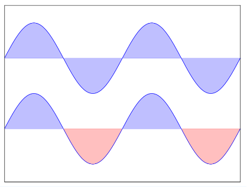

```python
display(Image('C://Users//Dar1//Documents//she_codes//python//finalmatplotlib//1.png',
              width=200, height=200))
```

### 2. Bar Plots

Starting from the code below, try to reproduce the graphic below by adding labels for red bars.

```
n = 12
X = np.arange(n)
Y1 = (1 - X / float(n)) * np.random.uniform(0.5, 1.0, n)
Y2 = (1 - X / float(n)) * np.random.uniform(0.5, 1.0, n)

plt.bar(X, +Y1, facecolor='#9999ff', edgecolor='white')
plt.bar(X, -Y2, facecolor='#ff9999', edgecolor='white')

for x, y in zip(X, Y1):
    plt.text(x + 0.4, y + 0.05, '%.2f' % y, ha='center', va='bottom')

plt.ylim(-1.25, +1.25)
```

**Hint**: You need to take care of text alignment.

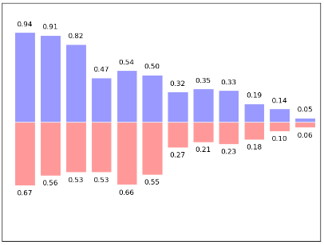

```python
display(Image('C://Users//Dar1//Documents//she_codes//python//finalmatplotlib//2.png',
              width=300, height=300))
```

### 3. Scatter plot I

Starting from the code below, try to reproduce the graphic below taking slices size.

```
import numpy as np
import matplotlib.pyplot as plt
import seaborn as sns

f, ax = plt.subplots(1, 1, figsize=(5,4))

x = np.linspace(0, 10, 1000)
y = np.power(x, 2)
```

**Hint**: read this [documentation](http://matplotlib.org/users/mathtext.html).

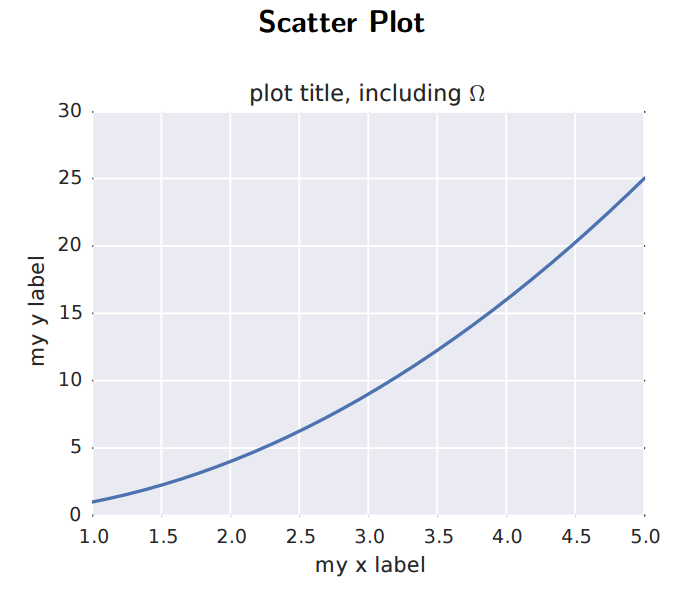

```python
display(Image('C://Users//Dar1//Documents//she_codes//python//finalmatplotlib//3.png',
              width=300, height=300))
```

### 4. Scatter plot II

Starting from the code below, try to reproduce the graphic below taking slices size.

```
x = np.linspace (0, 10, 50)
y1 = np.power(x, 2)
y2 = np.power(x, 3)
```

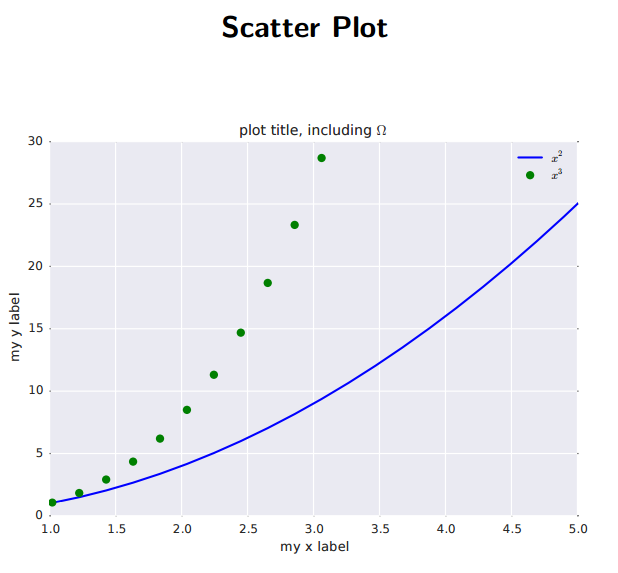

```python
display(Image('C://Users//Dar1//Documents//she_codes//python//finalmatplotlib//4.png',
              width=400, height=400))
```

### 5. Histogram

Create 2 histograms from two sub-plots (`ax1` and `ax2`) as shown below.

```
data = np.random.randn(1000)
f, (ax1, ax2) = plt.subplots(1, 2, figsize =(6,3))
```

**Hint**: set for both `normed=True` and for the second `cumulative=True`

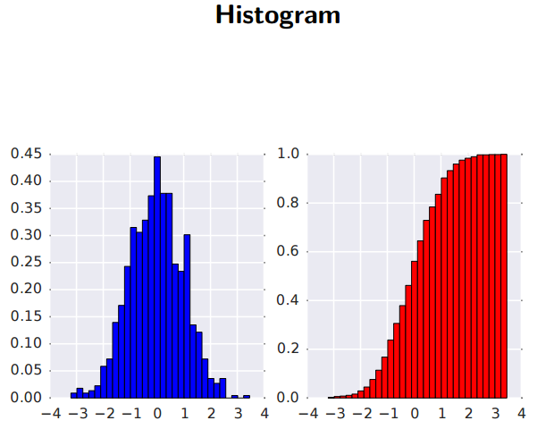

```python
display(Image('C://Users//Dar1//Documents//she_codes//python//finalmatplotlib//5.png',
              width=300, height=300))
```

### 6. Box plot

Starting from the code below, try to reproduce the graphic below.

```
samp1 = np.random.normal(loc=0., scale=1., size=100)
samp2 = np.random.normal(loc=1., scale=2., size=100)
samp3 = np.random.normal(loc=0.3, scale=1.2, size=100)
f, ax = plt.subplots(1, 1, figsize=(5,4))
```

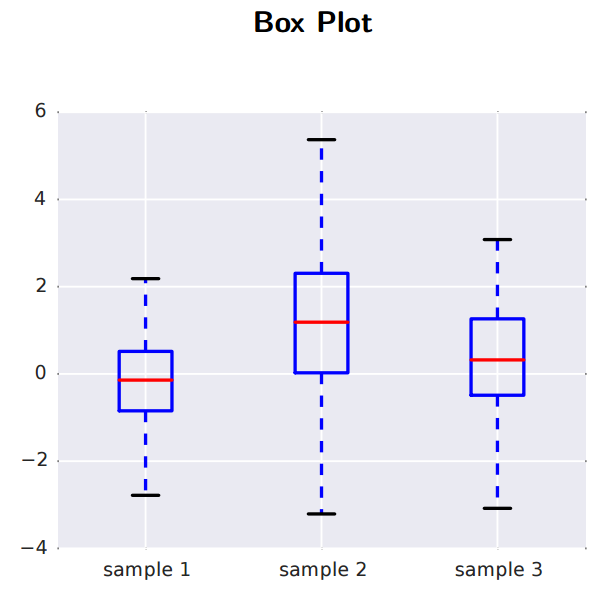

```python
display(Image('C://Users//Dar1//Documents//she_codes//python//finalmatplotlib//6.png',
              width=300, height=300))
```

### 7. Image Plot

Starting from the code below, try to reproduce the graphic below.

```
A = np.random.random((100, 100))
```

**Hints**:

1. To show A image use `imshow` function.
2. To get the colors use `hot` function.
3. To add a color bar use `colorbar` function.

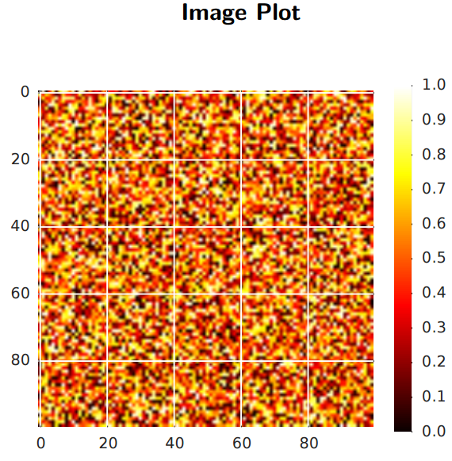

```python
display(Image('C://Users//Dar1//Documents//she_codes//python//finalmatplotlib//7.png',
              width=300, height=300))
```

### 8. Wire plot

Try to reproduce the graphic below, using the test data.

**Hint**: recall 3D graphs and `plot_wireframe`.

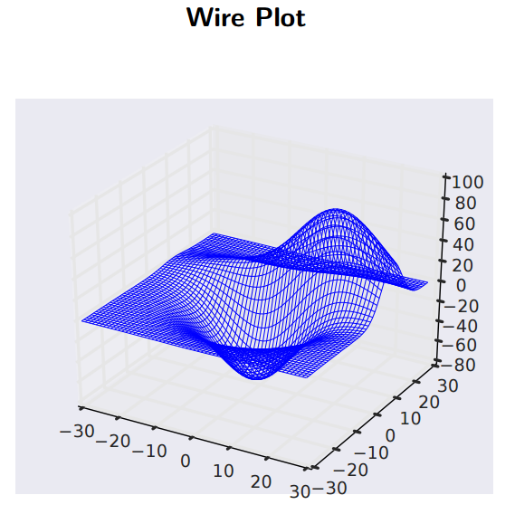

```python
display(Image('C://Users//Dar1//Documents//she_codes//python//finalmatplotlib//8.png',
              width=300, height=300))
```

# Solutions

**Note**: Solutions for questions 3-8 are shown on the same window

1. [Regular plot](http://www.scipy-lectures.org/intro/matplotlib/auto_examples/plot_plot_ex.html)
2. [Bar plots](http://www.scipy-lectures.org/intro/matplotlib/auto_examples/plot_bar_ex.html)
3. [Scatter plot I](https://drive.google.com/open?id=0B9crmgoWupXkckt2Zi0yM1FQeVU)
4. [Scatter plot II](https://drive.google.com/open?id=0B9crmgoWupXkckt2Zi0yM1FQeVU)
5. [Histogram](https://drive.google.com/open?id=0B9crmgoWupXkckt2Zi0yM1FQeVU)
6. [Box plot](https://drive.google.com/open?id=0B9crmgoWupXkckt2Zi0yM1FQeVU)
7. [Image Plot](https://drive.google.com/open?id=0B9crmgoWupXkckt2Zi0yM1FQeVU)
8. [Wire plot](https://drive.google.com/open?id=0B9crmgoWupXkckt2Zi0yM1FQeVU)